# Claiborne

Topics that will be discussed in this summary report for Claiborne County are

- Demographic Characteristics
  - Population growth from 1970 to 2020;
  - population density
  - sex, race, and age
  - educational level of the adult population
  - housing characteristics in terms of age of the housing stock and type of tenure
- Economic Characteristics
  - family income, household income, per capita income,
  - poverty status of families;
  - employment classification according to industry;
  - labor force by place of work and commuting patterns;

For more details on the data used, please see the Data Description tab.

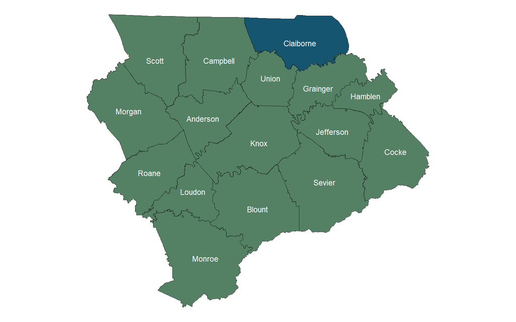

**Population and Growth**

| Place | 1970 | 1980 | 1990 | 2000 | 2010 | 2020 | Change 1970-1980 | Change 1980-1990 | Change 1990-2000 | Change 2000-2010 | Change 2010-2020 |
| --- | --- | --- | --- | --- | --- | --- | --- | --- | --- | --- | --- |
| Claiborne County | 19420 | 24595 | 26137 | 29862 | 32213 | 32043 | 5175 | 1542 | 3725 | 2351 | -170 |
| Cumberland Gap |  | 263 | 210 | 204 | 494 | 313 |  | -53 | -6 | 290 | -181 |
| Harrogate |  |  |  |  | 4389 | 4400 |  |  |  |  | 11 |
| New Tazewell | 1192 | 1677 | 1864 | 2871 | 3037 | 2769 | 485 | 187 | 1007 | 166 | -268 |
| Tazewell | 1860 | 2090 | 2150 | 2165 | 2218 | 2348 | 230 | 60 | 15 | 53 | 130 |

[interactive chart not shown]

IPUMS NHGIS, University of Minnesota, www.nhgis.org

**Population Density**

| Place | Area | Population Density |
| --- | --- | --- |
| Claiborne County | 441.459524052707 | 72.58423083918856 |
| Cumberland Gap | 0.3288951009927507 | 951.6712138770926 |
| Harrogate | 7.262763358431381 | 605.8300102662737 |
| New Tazewell | 5.065439785463106 | 546.6455268003635 |
| Tazewell | 4.339638677472904 | 541.0588702208055 |

[interactive chart not shown]

source: U. S. Census Bureau *Decennial Census: Redistricting Data (PL 94-171)*, 2020, accessed June 2, 2026, http://api.census.gov/data/2020/dec/pl.

**Population Descriptions**

| Place | Year | Race Category | Number of People | Percentage of People |
| --- | --- | --- | --- | --- |
| Claiborne County | 2020 | Black | 315 | 0.007522747355097557 |
| Claiborne County | 2020 | Other | 1553 | 0.03708833854751271 |
| Claiborne County | 2020 | White | 30175 | 0.7206314331430755 |
| Cumberland Gap | 2020 | Black | 9 | 0.000214935638717073 |
| Cumberland Gap | 2020 | Other | 35 | 0.0008358608172330618 |
| Cumberland Gap | 2020 | White | 269 | 0.006424187423876961 |
| Harrogate | 2020 | Black | 102 | 0.002435937238793495 |
| Harrogate | 2020 | Other | 300 | 0.007164521290569102 |
| Harrogate | 2020 | White | 3998 | 0.0954791870656509 |
| New Tazewell | 2020 | Black | 32 | 0.0007642156043273709 |

[output cut: 5 more lines]

| Place | Sex | Age Range | Year | Number of People | Percentage of People |
| --- | --- | --- | --- | --- | --- |
| Claiborne County | Female | 10 to 14 years | 2020 | 811 | 0.01952993305399027 |
| Claiborne County | Female | 15 to 19 years | 2020 | 953 | 0.02294947743582334 |
| Claiborne County | Female | 20 to 24 years | 2020 | 1142 | 0.02750084284544623 |
| Claiborne County | Female | 25 to 29 years | 2020 | 1179 | 0.02839185088859991 |
| Claiborne County | Female | 30 to 34 years | 2020 | 841 | 0.02025237200789867 |
| Claiborne County | Female | 35 to 39 years | 2020 | 761 | 0.01832586813080961 |
| Claiborne County | Female | 40 to 44 years | 2020 | 990 | 0.02384048547897703 |
| Claiborne County | Female | 45 to 49 years | 2020 | 1074 | 0.02586331454992053 |
| Claiborne County | Female | 5 to 9 years | 2020 | 780 | 0.01878341280161826 |
| Claiborne County | Female | 50 to 54 years | 2020 | 1133 | 0.02728411115927371 |

[output cut: 170 more lines]

[interactive chart not shown]

source: U. S. Census Bureau *Decennial Census: Redistricting Data (PL 94-171)*, 2020, accessed June 2, 2026, http://api.census.gov/data/2020/dec/pl.

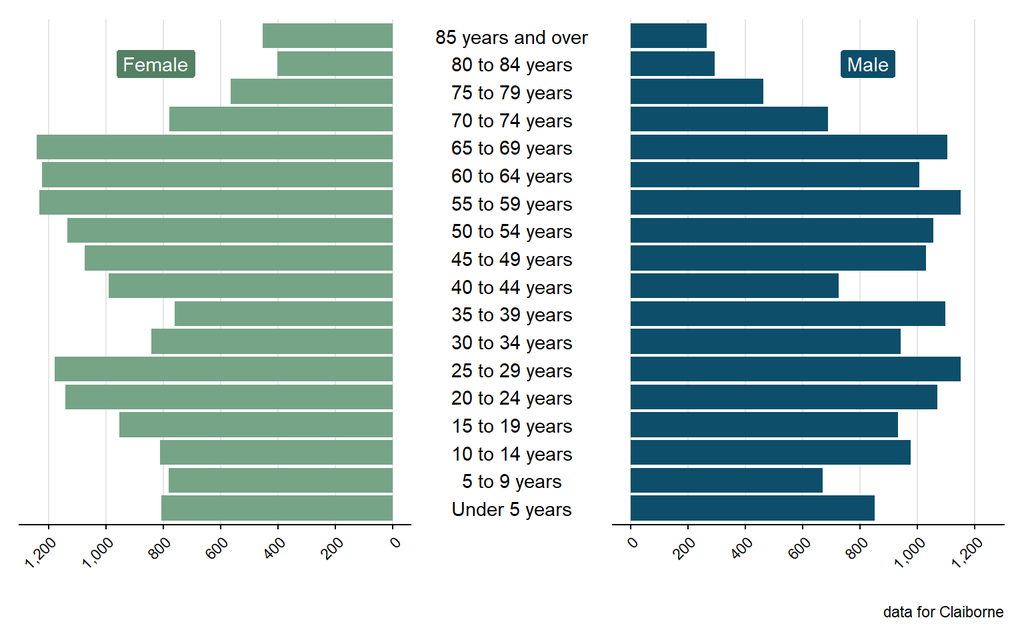

source: U. S. Census Bureau *American Community Survey 5-Year Estimates: Comparison Profiles 5-Year*, 2020, accessed June 2, 2026, http://api.census.gov/data/2020/acs/acs5.

**Education**

| Place | Level of Education | Year | Number of People | Percentage of People |
| --- | --- | --- | --- | --- |
| Claiborne County | 9th to 12th Grade, No Diploma | 2010 | 2775 | 0.09562700299803577 |
| Claiborne County | Associate's degree | 2010 | 983 | 0.03387435817912402 |
| Claiborne County | Bachelor's degree | 2010 | 1329 | 0.04579758089527551 |
| Claiborne County | Graduate or Professional Degree | 2010 | 1109 | 0.03821634101795376 |
| Claiborne County | Less Than 9th Grade | 2010 | 3605 | 0.1242289534442951 |
| Claiborne County | Some College, No Degree | 2010 | 3263 | 0.1124435714531858 |
| Claiborne County | Total | 2010 | 22047 | 0.7597436162514215 |
| Claiborne County | 9th to 12th Grade, No Diploma | 2020 | 1890 | 0.06353368293666802 |
| Claiborne County | Associate's degree | 2020 | 1924 | 0.06467661691542288 |
| Claiborne County | Bachelor's degree | 2020 | 2340 | 0.07866075030254134 |

[output cut: 60 more lines]

[interactive chart not shown]

source: U. S. Census Bureau *American Community Survey 5-Year Estimates: Comparison Profiles 5-Year*, 2020, accessed June 2, 2026, http://api.census.gov/data/2020/acs/acs5.

**Housing Units by Year of Construction**

| Place | Year | 1939 or earlier | 1940-1959 | 1960-1979 | 1980 to 1989 | 1990 to 1999 | 2000 to 2004 | 2005 or later | 2000 to 2009 | 2010 or later | Total |
| --- | --- | --- | --- | --- | --- | --- | --- | --- | --- | --- | --- |
| Claiborne County | 2010 | 1176 | 1630 | 4387 | 2575 | 3197 | 1340 | 446 |  |  | 14751 |
| Claiborne County | 2020 | 1209 | 1302 | 4244 | 2262 | 2727 |  |  | 2899 | 896 | 15539 |
| Cumberland Gap | 2010 | 29 | 5 | 36 | 29 | 22 | 47 | 0 |  |  | 168 |
| Harrogate | 2010 | 186 | 191 | 742 | 311 | 236 | 52 | 54 |  |  | 1772 |
| New Tazewell | 2010 | 26 | 262 | 451 | 396 | 400 | 52 | 8 |  |  | 1595 |
| Tazewell | 2010 | 123 | 155 | 493 | 205 | 119 | 41 | 15 |  |  | 1151 |
| Cumberland Gap | 2020 | 61 | 13 | 13 | 13 | 3 |  |  | 20 | 8 | 131 |
| Harrogate | 2020 | 210 | 97 | 700 | 293 | 298 |  |  | 238 | 58 | 1894 |
| New Tazewell | 2020 | 71 | 98 | 389 | 169 | 252 |  |  | 126 | 125 | 1230 |
| Tazewell | 2020 | 59 | 135 | 481 | 148 | 140 |  |  | 145 | 33 | 1141 |

[interactive chart not shown]

source: U. S. Census Bureau *Decennial Census: Redistricting Data (PL 94-171)*, 2020, accessed June 2, 2026, http://api.census.gov/data/2020/dec/pl.

**Housing Units by Type of Tenure**

| Place | Year | Own | Rent | Total |
| --- | --- | --- | --- | --- |
| Claiborne County | 2010 | 9666 | 2846 | 12512 |
| Claiborne County | 2020 | 9608 | 3953 | 13561 |
| Cumberland Gap | 2010 | 42 | 70 | 112 |
| Harrogate | 2010 | 1298 | 294 | 1592 |
| New Tazewell | 2010 | 822 | 519 | 1341 |
| Tazewell | 2010 | 637 | 393 | 1030 |
| Cumberland Gap | 2020 | 55 | 51 | 106 |
| Harrogate | 2020 | 1203 | 483 | 1686 |
| New Tazewell | 2020 | 490 | 708 | 1198 |
| Tazewell | 2020 | 604 | 451 | 1055 |

[interactive chart not shown]

source: U. S. Census Bureau *Decennial Census: Redistricting Data (PL 94-171)*, 2020, accessed June 2, 2026, http://api.census.gov/data/2020/dec/pl.

**Income Comparison**

| Place | Year | Median Family Income | Median Household Income | Per Capita Income |
| --- | --- | --- | --- | --- |
| Claiborne County | 2020 | 52404 | 37954 | 22562 |
| Cumberland Gap | 2020 | 90250 | 56250 | 18242 |
| Harrogate | 2020 | 62784 | 50938 | 29113 |
| New Tazewell | 2020 | 55952 | 37561 | 21595 |
| Tazewell | 2020 | 41515 | 37431 | 19365 |

[interactive chart not shown]

source: U. S. Census Bureau *Decennial Census: Redistricting Data (PL 94-171)*, 2020, accessed June 2, 2026, http://api.census.gov/data/2020/dec/pl.

**Povery Status**

| Place | Year | Above Poverty | Below Poverty |
| --- | --- | --- | --- |
| Claiborne County | 2020 | 7330 | 1420 |
| Cumberland Gap | 2020 | 45 | 5 |
| Harrogate | 2020 | 1012 | 39 |
| New Tazewell | 2020 | 631 | 116 |
| Tazewell | 2020 | 432 | 125 |

[interactive chart not shown]

source: U. S. Census Bureau *American Community Survey 5-Year Estimates: Comparison Profiles 5-Year*, 2020, accessed June 2, 2026, http://api.census.gov/data/2020/acs/acs5.

**Poverty Status by Family Type**

| Place | Poverty Status | Family Type | Number of Families | Year | Percentage of Families |
| --- | --- | --- | --- | --- | --- |
| Claiborne County | Above Poverty | All Families | 7330 | 2020 | 0.6571044374719857 |
| Claiborne County | Above Poverty | Female Householder | 772 | 2020 | 0.06920663379650381 |
| Claiborne County | Above Poverty | Female Householder with related children | 387 | 2020 | 0.03469296279695204 |
| Claiborne County | Below Poverty | All Families | 1420 | 2020 | 0.1272971761541909 |
| Claiborne County | Below Poverty | Female Householder | 333 | 2020 | 0.02985208426714478 |
| Claiborne County | Below Poverty | Female Householder with related children | 250 | 2020 | 0.02241147467503362 |
| Cumberland Gap | Above Poverty | All Families | 45 | 2020 | 0.004034065441506051 |
| Cumberland Gap | Above Poverty | Female Householder | 6 | 2020 | 0.0005378753922008068 |
| Cumberland Gap | Above Poverty | Female Householder with related children | 4 | 2020 | 0.0003585835948005379 |
| Cumberland Gap | Below Poverty | All Families | 5 | 2020 | 0.0004482294935006724 |

[output cut: 20 more lines]

[interactive chart not shown]

source: U. S. Census Bureau *American Community Survey 5-Year Estimates: Comparison Profiles 5-Year*, 2020, accessed June 2, 2026, http://api.census.gov/data/2020/acs/acs5.

**Employment by Industry**

| Place | Industry | Year | Number of Jobs | Percentage of Jobs |
| --- | --- | --- | --- | --- |
| Claiborne County | Arts, Entertainment, And Recreation, And Accommodation And Food Services | 2010 | 857 | 0.07040749260598093 |
| Claiborne County | Arts, Entertainment, And Recreation, And Accommodation And Food Services | 2020 | 704 | 5.415384615384616 |
| Claiborne County | Construction | 2010 | 818 | 0.06720341767992113 |
| Claiborne County | Construction | 2020 | 921 | 7.084615384615384 |
| Claiborne County | Educational Services, And Health Care And Social Assistance | 2010 | 2737 | 0.2248603351955307 |
| Claiborne County | Educational Services, And Health Care And Social Assistance | 2020 | 3819 | 29.37692307692308 |
| Claiborne County | Manufacturing | 2010 | 2525 | 0.2074433125205389 |
| Claiborne County | Manufacturing | 2020 | 2510 | 19.30769230769231 |
| Claiborne County | Other Industries | 2010 | 3711 | 0.3048800525796911 |
| Claiborne County | Other Industries | 2020 | 3474 | 26.72307692307692 |

[output cut: 50 more lines]

[interactive chart not shown]

source: U. S. Census Bureau *American Community Survey 5-Year Estimates: Comparison Profiles 5-Year*, 2020, accessed June 2, 2026, http://api.census.gov/data/2020/acs/acs5.

**Employment by Industry (Historical)**

| Place | Year | Industry | Number of Jobs | Percentage of Jobs |
| --- | --- | --- | --- | --- |
| Claiborne County | 2010 | Agriculture, Forestry, Fishing And Hunting, And Mining | 484 | 0.0299190208320455 |
| Claiborne County | 2010 | Construction | 818 | 0.05056561785250664 |
| Claiborne County | 2010 | Manufacturing | 2525 | 0.1560858008283365 |
| Claiborne County | 2010 | Other | 405 | 0.02503554429127774 |
| Claiborne County | 2010 | Professional Services | 4290 | 0.2651913210113124 |
| Claiborne County | 2010 | Public Administration | 693 | 0.04283859800951969 |
| Claiborne County | 2010 | Trade, Finance, Insurance &amp; Real Estate | 2957 | 0.1827903814056994 |
| Claiborne County | 2020 | Agriculture, Forestry, Fishing And Hunting, And Mining | 535 | 0.03175451092117759 |
| Claiborne County | 2020 | Construction | 921 | 0.05466524216524216 |
| Claiborne County | 2020 | Manufacturing | 2510 | 0.1489791073124407 |

[output cut: 60 more lines]

**Labor Force by Place of Work**

| Place | Year | Work Out Of State | Work Out of County of Residence | Work in County of Residence |
| --- | --- | --- | --- | --- |
| Claiborne County | 2020 | 1786 | 2101 | 8444 |
| Cumberland Gap | 2020 | 27 | 8 | 95 |
| Harrogate | 2020 | 557 | 164 | 1208 |
| New Tazewell | 2020 | 51 | 79 | 1187 |
| Tazewell | 2020 | 85 | 124 | 514 |

[interactive chart not shown]

source: U. S. Census Bureau *American Community Survey 5-Year Estimates: Comparison Profiles 5-Year*, 2020, accessed June 2, 2026, http://api.census.gov/data/2020/acs/acs5.

**Commuting Patterns**

| Home County | Year | Number of Jobs | Percentage of Jobs |
| --- | --- | --- | --- |
| Claiborne | 2010 | 5083 | 0.3453828905347557 |
| Claiborne | 2020 | 4659 | 0.3165726710606781 |
| Knox | 2020 | 434 | 0.02948970578242848 |
| Knox | 2010 | 315 | 0.02140381871305293 |
| Campbell | 2020 | 261 | 0.01773459264795814 |
| Campbell | 2010 | 252 | 0.01712305497044235 |
| Hamblen | 2020 | 165 | 0.01121152408778963 |
| Hamblen | 2010 | 147 | 0.009988448732758035 |
| Anderson | 2020 | 129 | 0.008765373377726439 |
| Anderson | 2010 | 72 | 0.004892301420126384 |

[output cut: 3 more lines]

| Work County | Year | Number of Jobs | Percentage of Jobs |
| --- | --- | --- | --- |
| Claiborne | 2010 | 5083 | 0.3453828905347557 |
| Claiborne | 2020 | 4659 | 0.3165726710606781 |
| Knox | 2020 | 1330 | 0.09037167901066794 |
| Knox | 2010 | 1216 | 0.08262553509546783 |
| Campbell | 2020 | 387 | 0.02629612013317932 |
| Campbell | 2010 | 367 | 0.02493714751647754 |
| Union | 2020 | 130 | 0.008833322008561528 |
| Union | 2010 | 129 | 0.008765373377726439 |
| Hancock | 2010 | 44 | 0.002989739756743901 |
| Hancock | 2020 | 40 | 0.002717945233403547 |

[output cut: 3 more lines]

[interactive chart not shown]

source: U. S. Census Bureau *Tn_od_main_JT00_2020*, LEHD Origin-Destination Employment Statistics, 8.3, 2020, accessed June 2, 2026, https://lehd.ces.census.gov/data/lodes/.

## References

Bureau, U. S. Census. *American Community Survey 5-Year Estimates: Comparison Profiles 5-Year*. 2020. Accessed June 2, 2026. http://api.census.gov/data/2020/acs/acs5.

Bureau, U. S. Census. *Decennial Census: Redistricting Data (PL 94-171)*. 2020. Accessed June 2, 2026. http://api.census.gov/data/2020/dec/pl.

Bureau, U. S. Census. *Tn_od_main_JT00_2020*. LEHD Origin-Destination Employment Statistics, 8.3. 2020. Accessed June 2, 2026. https://lehd.ces.census.gov/data/lodes/.